# Forecasting COVID-19 Cases in NYC

Elena Rhenals

2020-05-25

COVID has been the topic of the day for the last 5 months. Gladly the country is doing better and slowly getting ready to reopen, and yet, there is so much we don’t know about this virus. Many data scientists are working hard to uncover new patterns and forecast the impact of the virus. I also decided to make my small contribution and put together this tutorial about time series forecasting using the COVID data.

In this tutorial, you will learn how to:

1. Create a time series object
2. Transform and decompose a time series
3. Interpret ACF and PACF plots
4. Forecast a time series using some simple and more sophisticated forecasting models
5. Evaluate models performance

You can use the same techniques to forecast any time series, be it sales, demand, call volume, etc.

## Forecasting

For the most part, forecasting is the same as predictive modeling, but it only uses past observations of the same variable to make predictions about the future. In this tutorial, I will be working with the data containing net new cases of COVID-19 in New York City. This data is publicly available on NYC Health public website: https://www1.nyc.gov/site/doh/covid/covid-19-data.page

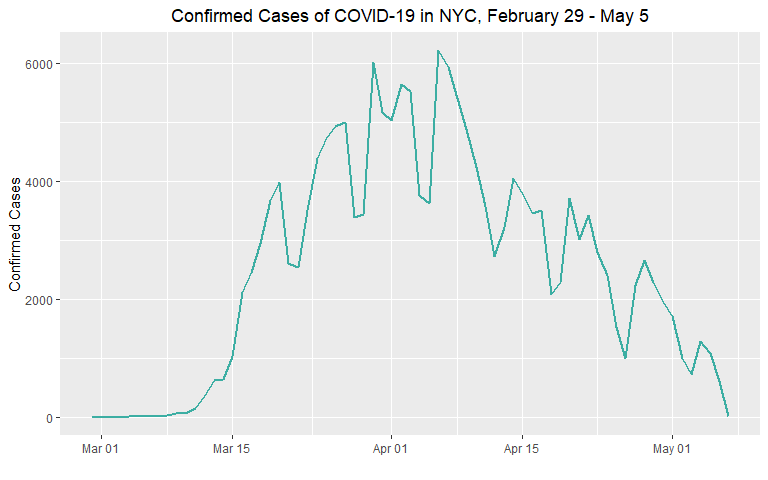

```r
ggplot(data=CasesConfirmed, aes(x=DATE, y=CASE_COUNT))+
  geom_line(size = 0.8, color="#3CAEA3")+
  ylab("Confirmed Cases")+
  xlab("")+
  ggtitle("Confirmed Cases of COVID-19 in NYC, February 29 - May 5")+
  theme(plot.title = element_text(hjust = 0.5))
```

It seems that the first case of coronavirus was recorded on February 29. Then the number of new cases remains pretty flat for the first week of March. Since this week does not contain relevant information for us, I will remove all observations before March 8, 2020.

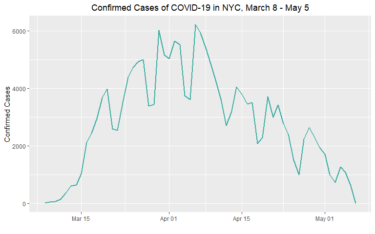

```r
ggplot(data=CasesConfirmed, aes(x=DATE, y=CASE_COUNT))+
  geom_line(size = 0.8, color="#3CAEA3")+
  ylab("Confirmed Cases")+
  xlab("")+
  ggtitle("Confirmed Cases of COVID-19 in NYC, March 8 - May 5")+
  theme(plot.title = element_text(hjust = 0.5))
```

## Creating a time series object

Many visualization and forecasting functions in R only work with time series objects. I highly recommend converting your data into a time series object to unlock all that functionality.

We can accomplish that with the ts() function. ts() requires specifying the frequency of the time series, which refers to the number of observations before the seasonal pattern repeats. For example, if you are working with monthly sales data, then your frequency would be 12.

If you are working with high-frequency data, it may get a little tricky. For example, the data that is observed every minute may exhibit several seasonal patterns at the same time (e.g., hourly (60), daily (60x24), and weekly (60x24x7)). I recommend reading about complex seasonality in Rob Hyndman and George Athanasopoulos’ online textbook Forecasting: Principles and Practice. I suggest downloading it or bookmarking it in your web browser. I can guarantee that it will prove very useful to you in your forecasting projects.

Our data contains daily observations. Usually, for daily data, the frequency would be either 365 or 7. Since our data covers only a couple of weeks, we will set the frequency argument to 7.

```r
# Transforming data to a time series object with ts()
CasesConfirmedTs = ts(CasesConfirmed$CASE_COUNT, frequency = 7)
CasesConfirmedTs
```

```
## Time Series:
## Start = c(1, 1)
## End = c(9, 5)
## Frequency = 7
##  [1]   21   57   70  153  355  618  642 1028 2116 2447 2950 3678 3985 2600 2545
## [16] 3505 4390 4734 4924 4991 3386 3437 6015 5170 5026 5645 5518 3752 3616 6212
## [31] 5924 5406 4871 4240 3565 2717 3211 4055 3800 3453 3500 2080 2285 3714 3005
## [46] 3419 2786 2399 1516  997 2237 2652 2282 1949 1708 1003  721 1279 1083  604
## [61]    6
```

The ts() function also lets you specify your start and end periods. For example, if you are working with monthly sales data that starts on January 1, 2015, you should set the start argument to c(2015, 1) and frequency to 12.

## Decomposing Time Series

Once our data is transformed into a time series object, we can start analyzing it. This usually involves understanding the components of a time series that affect how it fluctuates over time. This is why time series analysis is called decomposition. In this section, we will cover it only at a high level, but we’ll do a deeper dive later on in this tutorial.

A time series would usually have one or more of the following components:

1. Trend: upward or downward movement in observations over time
2. Seasonality: trend occurring at known time intervals
3. Cycle: longer-term upward or downward changes that may follow a business or economic cycle
4. Autocorrelation: correlation between past and future values of a time series
5. Random variance: fluctuations that are free of any visible, repeating, and detectable patterns over time

We can quickly gain an insight into the time series composition by calling the decompose() function and plotting the results, as shown below.

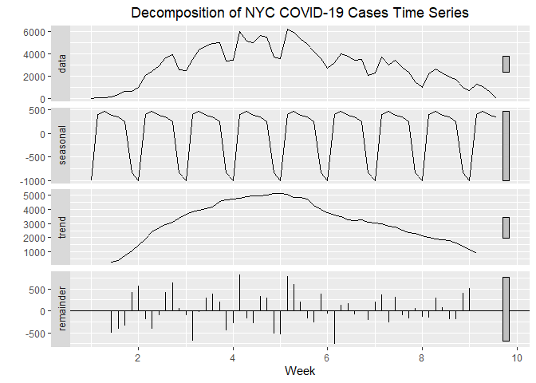

```r
CasesConfirmedTs %>% decompose(type="additive") %>%
  autoplot() + xlab("Week") +
  ggtitle("Decomposition of NYC COVID-19 Cases Time Series")+
  theme(plot.title = element_text(hjust =0.5))
```

The decomposition plot shows that our time series has a clear weekly seasonality and an upward trend in weeks 1 through 4, followed by a downward trend, starting at week 5. With this information, we can build a couple of simple forecasting models commonly used in the real world.

## Forecasting with Simple Models

In this section, I will cover the naive method with seasonality, the naive method with a trend, also known as the random walk model, and exponential smoothing with a trend and seasonality. Later on, we will cover more complex models such as ARIMA and seasonal ARIMA models.

Note that there are many other forecasting methods available, in addition to what I will cover in this tutorial. I strongly recommend that you familiarize yourself with those methods to understand what may be the best fit for your data. You can start with the same Hyndman and Athanasopoulos’ textbook I mentioned above.

Before modeling, we need to create a training set using 46 observations, leaving the rest of 15 for testing.

```r
#Create a training set
train <- subset(CasesConfirmedTs, end=length(CasesConfirmedTs)-15)
```

#### Naive Model

Now, let’s see how naive models work.

```r
#Fit and forecast seasonal naive model
naive.fit <- snaive(train, h=15)
knitr::kable(naive.fit)
```

|  | Point Forecast | Lo 80 | Hi 80 | Lo 95 | Hi 95 |
| --- | --- | --- | --- | --- | --- |
| 7.571429 | 3453 | 1469.53874 | 5436.461 | 419.55777 | 6486.442 |
| 7.714286 | 3500 | 1516.53874 | 5483.461 | 466.55777 | 6533.442 |
| 7.857143 | 2080 | 96.53874 | 4063.461 | -953.44223 | 5113.442 |
| 8.000000 | 2285 | 301.53874 | 4268.461 | -748.44223 | 5318.442 |
| 8.142857 | 3714 | 1730.53874 | 5697.461 | 680.55777 | 6747.442 |
| 8.285714 | 3005 | 1021.53874 | 4988.461 | -28.44223 | 6038.442 |
| 8.428571 | 3419 | 1435.53874 | 5402.461 | 385.55777 | 6452.442 |
| 8.571429 | 3453 | 647.96218 | 6258.038 | -836.93514 | 7742.935 |
| 8.714286 | 3500 | 694.96218 | 6305.038 | -789.93514 | 7789.935 |
| 8.857143 | 2080 | -725.03782 | 4885.038 | -2209.93514 | 6369.935 |
| 9.000000 | 2285 | -520.03782 | 5090.038 | -2004.93514 | 6574.935 |
| 9.142857 | 3714 | 908.96218 | 6519.038 | -575.93514 | 8003.935 |
| 9.285714 | 3005 | 199.96218 | 5810.038 | -1284.93514 | 7294.935 |
| 9.428571 | 3419 | 613.96218 | 6224.038 | -870.93514 | 7708.935 |
| 9.571429 | 3453 | 17.54432 | 6888.456 | -1801.07606 | 8707.076 |

```r
#Fit and forecast random walk model with a trend
drif.fit <- rwf(train, h=15, drift=TRUE)
knitr::kable(drif.fit)
```

|  | Point Forecast | Lo 80 | Hi 80 | Lo 95 | Hi 95 |
| --- | --- | --- | --- | --- | --- |
| 7.571429 | 3494.511 | 2362.49356 | 4626.529 | 1763.2397 | 5225.783 |
| 7.714286 | 3570.022 | 1951.41745 | 5188.627 | 1094.5798 | 6045.465 |
| 7.857143 | 3645.533 | 1641.72371 | 5649.343 | 580.9710 | 6710.096 |
| 8.000000 | 3721.044 | 1382.75905 | 6059.330 | 144.9455 | 7297.143 |
| 8.142857 | 3796.556 | 1155.18128 | 6437.930 | -243.0778 | 7836.189 |
| 8.285714 | 3872.067 | 949.20993 | 6794.923 | -598.0570 | 8342.190 |
| 8.428571 | 3947.578 | 759.11750 | 7136.038 | -928.7514 | 8823.907 |
| 8.571429 | 4023.089 | 581.22598 | 7464.952 | -1240.7862 | 9286.964 |
| 8.714286 | 4098.600 | 413.01788 | 7784.182 | -1538.0114 | 9735.211 |
| 8.857143 | 4174.111 | 252.68729 | 8095.535 | -1823.1891 | 10171.411 |
| 9.000000 | 4249.622 | 98.89121 | 8400.353 | -2098.3731 | 10597.618 |
| 9.142857 | 4325.133 | -49.39807 | 8699.665 | -2365.1351 | 11015.402 |
| 9.285714 | 4400.644 | -192.98550 | 8994.274 | -2624.7063 | 11425.995 |
| 9.428571 | 4476.156 | -332.51381 | 9284.825 | -2878.0696 | 11830.381 |
| 9.571429 | 4551.667 | -468.50465 | 9571.838 | -3126.0228 | 12229.356 |

Note that the same function that is used to fit the model also produces the forecast and prediction intervals.

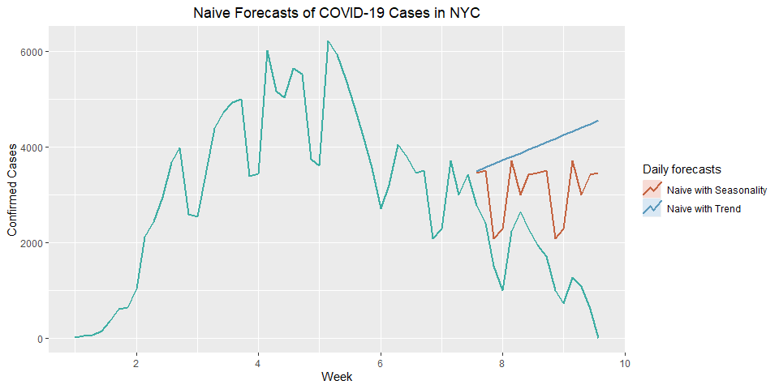

```r
#Plot Forecast vs. Actual for both models
autoplot(CasesConfirmedTs, main = "Naive Forecasts of COVID-19 Cases in NYC", ylab = "Confirmed Cases", xlab = "Week", color="#3CAEA3", size = 0.8) +
  autolayer(naive.fit, series="Naive with Seasonality", PI=FALSE, size = 0.8)+
  autolayer(drif.fit, series = "Naive with Trend", PI=FALSE, size = 0.8)+
  scale_color_manual(values = c("Naive with Seasonality" = "#ED553B", "Naive with Trend"="#20639B"))+
  guides(color=guide_legend(title="Daily forecasts"))+
  theme(plot.title = element_text(hjust = 0.5))
```

Compare the actual observations with the forecasts produced by the naive models. These models show a pretty high forecast error and clearly do not provide a good fit for our data, which was expected.

#### Exponential Smoothing with Trend and Seasonality

The next type of forecasting model we will cover is called exponential smoothing. Exponential smoothing models use weighted averages of past observations with higher weights for more recent observations and lower weights for older observations. Exponential smoothing models are very common as they can accommodate complex data containing trends and seasonality and are very simple to use.

These models also let us specify the nature of seasonal variations. If a time series fluctuates consistently over time, then the additive method should be selected. The multiplicative method should be used if the fluctuations increase or decrease over time.

Our data does show several larger spikes around weeks 3, 4, and 5, but the pattern does not seem consistent. Just to make sure we are not missing anything, we will fit both models, using the Holt-Winters method. In addition to the weights component, this method includes a trend component and a seasonal component. Thus, it should be a better fit for our time series.

```r
#Fit and forecast the Exponential smoothing model using Holt-Winters multiplicative method
es.fit.m <- hw(train, seasonal="multiplicative", h=15)
knitr::kable(es.fit.m)
```

|  | Point Forecast | Lo 80 | Hi 80 | Lo 95 | Hi 95 |
| --- | --- | --- | --- | --- | --- |
| 7.571429 | 3232.519 | 1863.3345 | 4601.703 | 1138.5322 | 5326.505 |
| 7.714286 | 3071.159 | 1324.7932 | 4817.525 | 400.3231 | 5741.995 |
| 7.857143 | 2115.713 | 574.1396 | 3657.286 | -241.9200 | 4473.346 |
| 8.000000 | 2016.461 | 187.8796 | 3845.042 | -780.1128 | 4813.034 |
| 8.142857 | 3101.691 | -329.4397 | 6532.822 | -2145.7706 | 8349.153 |
| 8.285714 | 2920.275 | -963.4924 | 6804.043 | -3019.4348 | 8859.985 |
| 8.428571 | 2830.764 | -1646.0707 | 7307.598 | -4015.9636 | 9677.491 |
| 8.571429 | 2770.688 | -2396.4442 | 7937.820 | -5131.7587 | 10673.135 |
| 8.714286 | 2623.238 | -3108.1342 | 8354.609 | -6142.1391 | 11388.614 |
| 8.857143 | 1800.573 | -2784.8919 | 6386.039 | -5212.2907 | 8813.438 |
| 9.000000 | 1709.574 | -3345.0946 | 6764.242 | -6020.8743 | 9440.021 |
| 9.142857 | 2619.148 | -6344.1555 | 11582.452 | -11089.0418 | 16327.338 |
| 9.285714 | 2455.627 | -7248.6145 | 12159.868 | -12385.7294 | 17296.983 |
| 9.428571 | 2369.879 | -8426.1855 | 13165.944 | -14141.2770 | 18881.036 |
| 9.571429 | 2308.879 | -9801.0296 | 14418.787 | -16211.6279 | 20829.386 |

```r
#Fit and forecast the Exponential smoothing model using the Holt-Winters additive method
es.fit.a <- hw(train, seasonal="additive", h=15)
knitr::kable(es.fit.a)
```

|  | Point Forecast | Lo 80 | Hi 80 | Lo 95 | Hi 95 |
| --- | --- | --- | --- | --- | --- |
| 7.571429 | 3235.5341 | 2345.01049 | 4126.058 | 1873.59576 | 4597.472 |
| 7.714286 | 3054.7116 | 2014.15712 | 4095.266 | 1463.32084 | 4646.102 |
| 7.857143 | 1765.5936 | 559.56973 | 2971.617 | -78.86073 | 3610.048 |
| 8.000000 | 1539.2058 | 154.12056 | 2924.291 | -579.09929 | 3657.511 |
| 8.142857 | 2864.2434 | 1287.89765 | 4440.589 | 453.43060 | 5275.056 |
| 8.285714 | 2884.5497 | 1105.80927 | 4663.290 | 164.20098 | 5604.898 |
| 8.428571 | 2657.4517 | 666.01384 | 4648.890 | -388.18969 | 5703.093 |
| 8.571429 | 2664.6654 | 450.85199 | 4878.479 | -721.07002 | 6050.401 |
| 8.714286 | 2483.8429 | 38.59916 | 4929.087 | -1255.83467 | 6223.520 |
| 8.857143 | 1194.7248 | -1490.59601 | 3880.046 | -2912.11898 | 5301.569 |
| 9.000000 | 968.3371 | -1965.32487 | 3901.999 | -3518.31169 | 5454.986 |
| 9.142857 | 2293.3747 | -896.56252 | 5483.312 | -2585.21328 | 7171.963 |
| 9.285714 | 2313.6809 | -1140.17756 | 5767.539 | -2968.53981 | 7595.902 |
| 9.428571 | 2086.5830 | -1638.58805 | 5811.754 | -3610.57446 | 7783.740 |
| 9.571429 | 2093.7966 | -1909.88314 | 6097.476 | -4029.30318 | 8216.896 |

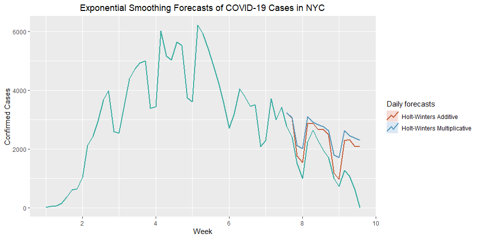

```r
#Plot Forecast vs. Actual for both exponential smoothing models
autoplot(CasesConfirmedTs, main = "Exponential Smoothing Forecasts of COVID-19 Cases in NYC", ylab = "Confirmed Cases", xlab = "Week", color="#3CAEA3", size = 0.8) +
  autolayer(es.fit.a, series="Holt-Winters Additive", PI=FALSE, size = 0.8)+
  autolayer(es.fit.m, series="Holt-Winters Multiplicative", PI=FALSE, size = 0.8)+
  scale_color_manual(values = c("Holt-Winters Additive" = "#ED553B", "Holt-Winters Multiplicative"="#20639B"))+
    guides(color=guide_legend(title="Daily forecasts"))+
  theme(plot.title = element_text(hjust = 0.5))
```

Both of these models produced much more accurate forecasts compared to the naive models. Looking at the actuals vs. forecasts, it appears that the additive method is slightly better than the multiplicative method.

Sometimes it’s hard to tell which forecast is better by just looking at the plot. To ensure that we correctly identify and select the best performing model, we need to calculate the forecast errors of each model and compare them.

## Model Performance Evaluation

The two most commonly used forecasting model performance measures are mean absolute error (MAE), and root mean squared error (RMSE). MAE is calculated by averaging all absolute forecast errors. RMSE is calculated by taking the square root of the average of squared forecast errors. The model with smaller MAE or RMSE has a better performance as it produces more accurate predictions.

I will go ahead and calculate MAE and RMSE for both of our exponential smoothing models and see which one is better. Luckily, we don’t have to calculate each of these measures separately because the accuracy() function calculates all the forecasting error measures for us.

```r
knitr::kable(accuracy(es.fit.a, CasesConfirmedTs))
```

|  | ME | RMSE | MAE | MPE | MAPE | MASE | ACF1 | Theil’s U |
| --- | --- | --- | --- | --- | --- | --- | --- | --- |
| Training set | -107.1783 | 606.1282 | 495.0830 | 79.66516 | 253.2089 | 0.3878714 | 0.0746227 | NA |
| Test set | -725.2197 | 890.2929 | 725.2197 | -2369.21052 | 2369.2105 | 0.5681713 | 0.5078152 | 2.113676 |

```r
knitr::kable(accuracy(es.fit.m, CasesConfirmedTs))
```

|  | ME | RMSE | MAE | MPE | MAPE | MASE | ACF1 | Theil’s U |
| --- | --- | --- | --- | --- | --- | --- | --- | --- |
| Training set | -66.79757 | 443.7662 | 362.7547 | 9.648421 | 80.04052 | 0.2841991 | -0.0101242 | NA |
| Test set | -981.61246 | 1107.5152 | 981.6125 | -2631.750181 | 2631.75018 | 0.7690415 | 0.5660774 | 2.499631 |

As expected, the additive model shows smaller MAE and RMSE; therefore, it’s a better fit.

## Forecasting Using ARIMA Models

Our next big topic is ARIMA models. There is a lot of ground to cover in this section because ARIMA models require a deeper understanding of the time series components.

Let’s begin.

ARIMA or Autoregressive Integrated Moving Average Model is another widely used forecasting approach, which consists of the following components or terms:

1. Autoregressive (AR) term uses correlations between observations of the same variable at different times or lags to make predictions. These correlations are usually referred to as autocorrelations.
2. Integrated (I) term refers to differencing, which is a way to stabilize the mean of a time series.
3. Moving Average (MA) term uses past forecast errors to predict future values.

To fit an ARIMA model, we need to analyze each of the model’s components and select the appropriate order. ARIMA models follow a specific order that can be written as ARIMA(p, d, q) where:

p is the order of the AR term

d is the differencing order

q is the order of the MA term

Later on, I will describe each of these terms in detail and show you how to determine the right order, but first, we need to cover a few important concepts.

#### Stationary vs. Non-stationary Time series

The first concept we will go over is stationarity in time series. A time series is considered stationary if its mean, variance, and autocorrelation structure do not change over time.

Why is this concept so important? Because it helps determine the right order of ARIMA models. To do that, we need to identify every component that makes the time series change over time and strip it away until the series becomes stationary.

#### Stabilizing Variance

A stationary time series maintains constant variance over time. If your time series fluctuations increase or decrease, then it’s called heteroscedastic. In the context of a time series, heteroscedasticity refers to non-constant variance exhibited by the time series over time.

The Box-Cox transformation is a common method used to transform a time series exhibiting non-constant variance. It uses the lambda parameter to inform the level of the transformation. The lambda parameter is nothing but an exponent, varying from -5 to 5. The optimal lambda is the one that results in the best approximation of a normal distribution curve.

Below are the most common Box-Cox Transformations:

| Lambda_Value | Transformed_Data |
| --- | --- |
| -3 | Y^-3 |
| -2 | Y^-2 |
| -1 | Y^-1 or inverse |
| -0.5 | Y^-0.5 |
| 0 | log(Y) |
| 0.5 | Y^0.5 or square root |
| 1 | Y or no transformation |
| 2 | Y^2 |
| 3 | Y^3 |

I will go ahead and calculate the optimal lambda for our time series.

```r
lambda <- BoxCox.lambda(CasesConfirmedTs)
lambda
```

```
## [1] 0.8032734
```

The optimal lambda for our data is 0.8. Note that it’s very close to 1 (which means no transformation), so our time series is more or less normally distributed. However, we will still proceed with the transformation.

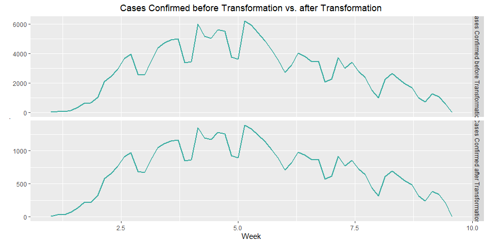

```r
#Box-Cox transformation
CasesConfirmedTs2 <- BoxCox(CasesConfirmedTs, lambda = lambda)

cases<-cbind("Cases Confirmed before Transformation"=CasesConfirmedTs, "Cases Confirmed after Transformation" = CasesConfirmedTs2)

cases %>% autoplot(facets=TRUE, main = "Cases Confirmed before Transformation vs. after Transformation", xlab="Week", color="#3CAEA3", size=0.8)+
  theme(plot.title = element_text(hjust = 0.5))
```

Compare the original time series (before the transformation) and after the transformation. If you look closely, you can see that the largest spike around week 5 got a little smoothed out. Again, since our lambda was close to 1, we do not expect to see drastic changes in the transformed series.

#### Non-Seasonal Differencing

If the Box-Cox transformation helps stabilize the variance, non-seasonal differencing helps stabilize the mean of a time series by removing any non-seasonal trends. It’s doing so by calculating increments or changes in the time series.

We can take daily stock prices as an example. Let’s say that this daily stock price series exhibits an upward trend. If we difference it at lag=1 (1 day), we will get daily price changes, which should remove the trend. If the trend persists, we may need to difference the time series again.

In R, this can be accomplished by the diff() command. This function takes two arguments. The first is the lag, which is the number of periods, and the second is differences, which is the order of the difference (e.g., how many times diff() is called).

Now, let’s see how it works.

```r
#Time series after differencing
CasesConfirmedTs3 <- diff(CasesConfirmedTs2, lag= 1)
CasesConfirmedTs3
```

```
## Time Series:
## Start = c(1, 2)
## End = c(9, 5)
## Frequency = 7
##  [1]   17.669173    5.747368   33.021905   68.407683   78.092875    6.753247
##  [7]  102.977139  256.997392   72.321347  106.346540  147.839604   60.565005
## [13] -281.983708  -11.734295  198.587833  173.646506   65.573668   35.813558
## [19]   12.563744 -311.568160   10.293114  489.454607 -154.774834  -26.854787
## [25]  114.423056  -23.265926 -336.052570  -27.036767  489.011048  -51.901077
## [31]  -94.626140  -99.627622 -120.331643 -132.714643 -174.077226  102.526173
## [37]  168.335022  -50.061040  -69.202627    9.450651 -298.933371   45.178347
## [43]  296.476228 -143.590148   84.565879 -130.217412  -82.458754 -199.194460
## [49] -127.707673  291.622140   89.459002  -79.610034  -73.850390  -54.998429
## [55] -171.080690  -74.682144  143.819083  -48.750647 -127.675879 -208.088127
```

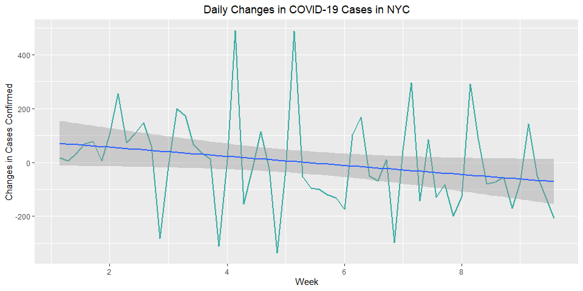

```r
autoplot(CasesConfirmedTs3, main = "Daily Changes in COVID-19 Cases in NYC", xlab = "Week", ylab = "Changes in Cases Confirmed", size=0.8, color = "#3CAEA3")+
  theme(plot.title = element_text(hjust = 0.5))+
  geom_smooth(method = "lm")
```

This is how our time series looks after we differenced it once. It appears there is still some trend remaining in our data. This means that we need to difference the series again.

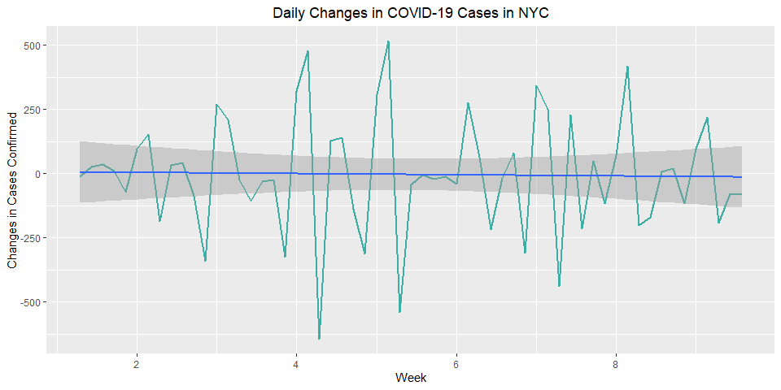

```r
#second differencing
CasesConfirmedTs3 <- diff(CasesConfirmedTs3)

#plot the results
autoplot(CasesConfirmedTs3, main = "Daily Changes in COVID-19 Cases in NYC", xlab = "Week", ylab = "Changes in Cases Confirmed", size=0.8, color = "#3CAEA3")+
  theme(plot.title = element_text(hjust = 0.5))+
  geom_smooth(method = "lm")
```

This looks much better! Now, our series fluctuates around a straight horizontal line.

#### Seasonal Differencing

Unlike non-seasonal differencing, seasonal differencing stabilizes the mean of a time series by removing seasonal trends. It works exactly the same way as non-seasonal differencing, except that the lag argument in the diff() function needs to be set to the seasonal frequency of the time series.

If you are unsure whether the data you are working with has seasonal patterns, we can use a couple of tools in R to find that out. One of my favorite tools for that is the ggseasonplot() function from the forecast package that quickly visualizes seasonal trends. Here is how you can use it.

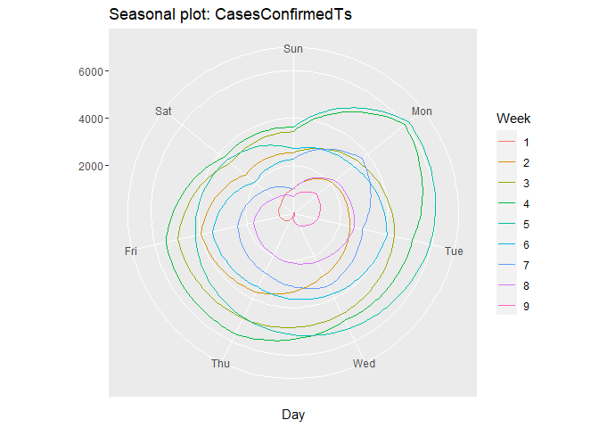

```r
ggseasonplot(CasesConfirmedTs, polar = TRUE) +
  labs(color = "Week")
```

I find that the polar plot is easier to work with because any seasonal pattern becomes easier to spot when you put it in the polar coordinates. For example, here, we can see right away that the number of new coronavirus cases usually goes down on weekends. This makes perfect sense because many testing facilities are closed on the weekend I would imagine.

Another great tool to spot seasonal patterns is ACF/PACF plots that we will cover in greater detail when we talk about autoregressive models. For now, I will only show you how to use them to identify seasonality.

These plots calculate correlations between observation and some number of lagged observations. The trick is to look at the spikes that are repeating at the same interval. For example, if you are working with monthly sales data, you should examine lag 12, 24, 36, etc. for any significant spikes (above or below the blue line). If you notice them, that means that your time series exhibits seasonal behavior with the frequency equal to the interval at which the spikes reocurr. For the purpose of this exercise, it does not matter whether the ACF or the PACF plot exhibits seasonality. One of them or both should detect seasonality if it’s present in the data.

We will now go ahead and generate ACF and PACF using the acf2() command from the astsa package. We already know that our data has a seasonal pattern that repeats every 7 days, so we will look for spikes at every weekly lag.

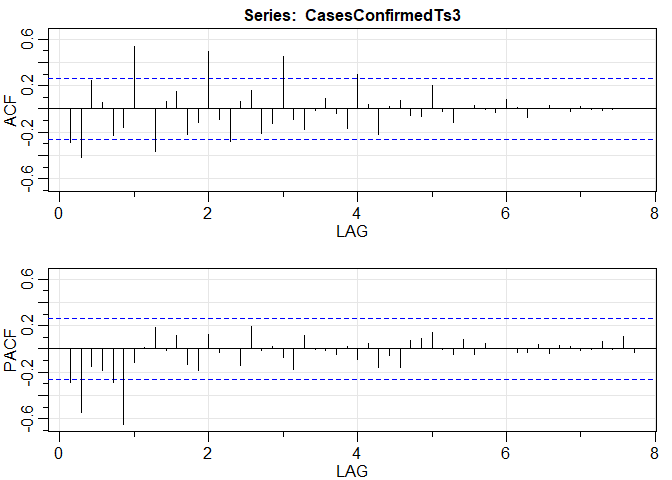

```
##       [,1]  [,2]  [,3]  [,4]  [,5]  [,6]  [,7] [,8]  [,9] [,10] [,11] [,12]
## ACF  -0.29 -0.42  0.24  0.05 -0.22 -0.16  0.54 0.00 -0.36  0.06  0.15 -0.22
## PACF -0.29 -0.54 -0.15 -0.18 -0.28 -0.65 -0.11 0.02  0.18 -0.01  0.12 -0.14
##      [,13] [,14] [,15] [,16] [,17] [,18] [,19] [,20] [,21] [,22] [,23] [,24]
## ACF  -0.11  0.50 -0.09 -0.28  0.06  0.16 -0.21 -0.12  0.45 -0.09 -0.17 -0.01
## PACF -0.18  0.12 -0.03  0.00 -0.14  0.19 -0.01  0.02 -0.07 -0.18  0.12 -0.01
##      [,25] [,26] [,27] [,28] [,29] [,30] [,31] [,32] [,33] [,34] [,35] [,36]
## ACF   0.09 -0.04 -0.17  0.30  0.04 -0.22  0.02  0.07 -0.06 -0.07  0.20 -0.02
## PACF -0.01 -0.05  0.02 -0.09  0.05 -0.16 -0.06 -0.16  0.07  0.09  0.14  0.00
##      [,37] [,38] [,39] [,40] [,41] [,42] [,43] [,44] [,45] [,46] [,47] [,48]
## ACF  -0.11  0.00  0.03 -0.01 -0.03  0.08  0.01 -0.07  0.00  0.03  0.00 -0.02
## PACF -0.05  0.08 -0.05  0.05  0.00  0.00 -0.03 -0.03  0.04 -0.04  0.03  0.02
##      [,49] [,50] [,51] [,52] [,53] [,54]
## ACF   0.03  0.00 -0.01     0   0.0  0.00
## PACF -0.01 -0.01  0.07     0   0.1 -0.03
```

```r
#Generate ACF and PACF plots
acf2(CasesConfirmedTs3, max.lag= 54)
```

Looking at the ACF plot, we can see the spikes at the 1st three weekly lags, which confirms that our data exhibits weekly seasonality.

To determine the seasonal differencing order (i.e., how many times, if any, we need to seasonally difference our data), we can use the nsdiffs() function from the forecast package.

```r
CasesConfirmedTs3 %>% nsdiffs()
```

```
## [1] 1
```

According to nsdiff() our data needs first order seasonal differencing to remove the seasonal trend. We can do it using the same diff() function, but this time setting the lag to 7.

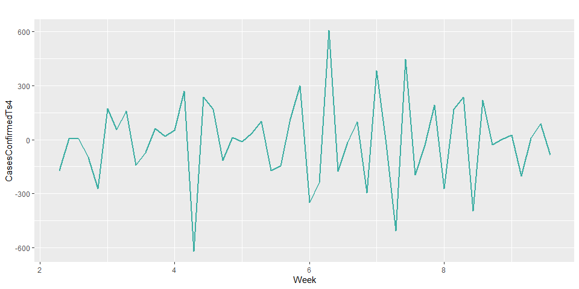

```r
#1st order seasonal differencing
CasesConfirmedTs4 <- diff(CasesConfirmedTs3, lag=7)

#plot the resulting series
autoplot(CasesConfirmedTs4, main = "", xlab = "Week", size = 0.8, color = "#3CAEA3")
```

This is how our time series looks after the second order non-seasonal and first order seasonal differencing. It certainly appears more random now that we removed the general trend and seasonality.

#### Autoregressive Models

Next, in this tutorial, I will explain the AR term of ARIMA model. AR stands for autoregressive models. These models are similar to linear regression, but instead of different independent variables, we use the same variable at different times. Let’s look at the stock prices, for example. Yesterday’s price (lag = 1) and the day before yesterday’s price (lag = 2) may be good indicators of the price today (lag = 0).

The simplest autoregressive model is the first order AR model or AR(1). To fit AR(1) model, we can use the arima() function by specifying the order = 1,0,0.

#### Moving Average Models

Instead of using correlations between observations at different times, ARIMA’s Moving Average (MA) model uses past forecast errors to make predictions. The Moving Average process can be thought of as a weighted moving average of the past few forecast errors. How many forecast errors to include would depend on the order of the MA model.

The first order Moving Average model or MA(1) uses the forecast error or residual of the current observation, and that of the previous observation, multiplied by some coefficient. To fit MA(1), we can use the arima() function by specifying the order = 0,0,1.

#### Using ACF and PACF to Determine ARIMA Model Order

As briefly discussed above, ACF, or autocorrelation function, visualizes correlation scores (from -1 to 1) between observations at different times. The PACF plot does the same but using partial correlations.

Instead of common bi-variate correlations that measure the correlation between two variables (such as the case in ACF), partial correlations measure the correlations between observation and some number of lagged observations, having removed the variance that was already explained by the previous lags. Hence the name, partial correlations.

We can use the same stock price example to explain partial correlations. We know that today’s stock price correlates with the price yesterday and the day before yesterday. According to the same logic, it is very likely that yesterday’s price is also correlated with the day before yesterday’s price. If we include both lags in our model to predict today’s price, our model is likely to suffer from multicollinearity.

The PACF plot can help us prevent that since it only shows remaining correlations. For the two stock price lags (yesterday and the day before yesterday), PACF will likely show a spike at lag 1 and, perhaps, lag 2 in case a significant portion of the variance that remained unexplained by yesterday’s price can be explained by the price the day before yesterday.

Let’s do a practice exercise and try to determine ARIMA’s order by analyzing ACF and PACF. We can reference the table below that describes behaviors of ACF and PACF plots characteristic to AR, MA, and ARMA (both AR and MA terms present) models.

|  | AR(p) | MA(q) | ARMA(p.q) |
| --- | --- | --- | --- |
| ACF | Tails off | Cuts off after lag q | Tails off |
| PACF | Cuts off after lag p | Tails off | Tails off |

According to this table, we should rely on PACF to determine the order of the AR term, and ACF to determine the order of the MA term. ARMA models are more complicated and hard to spot from ACF/PACF plots.

Now, let’s practice.

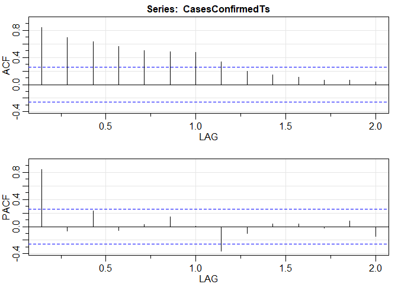

```
##      [,1]  [,2] [,3]  [,4] [,5] [,6] [,7]  [,8] [,9] [,10] [,11] [,12] [,13]
## ACF  0.84  0.69 0.63  0.57 0.50 0.48 0.47  0.34  0.2  0.15  0.11  0.06  0.06
## PACF 0.84 -0.07 0.23 -0.06 0.03 0.14 0.01 -0.36 -0.1  0.04  0.04 -0.02  0.08
##      [,14]
## ACF   0.04
## PACF -0.14
```

```r
acf2(CasesConfirmedTs, max.lag = 14)
```

These ACF and PACF are generated using the original time series (before any transformations). The plots suggest an AR(1) model because ACF is tailing off, and PACF cuts off after the first lag. Thus, based on our ACF and PACF analysis, we would build ARIMA(1,2,0) model where: AR term order = 1 Differencing order = 2 (based on our analysis above) MA term = 0

Note that if the spikes are tailing off very slowly (like in this example), it usually means that the time series is not stationary.

#### Seasonal ARIMA Models

ARIMA can also accommodate time series with seasonality using a seasonal ARIMA model. ARIMA’s seasonal model has a slightly different structure. It incorporates both non-seasonal and seasonal terms in the following order, ARIMA(p,d,q)x(P,D,Q)S where:

P = seasonal AR order (SAR)

D = seasonal differencing

Q = seasonal MA order (SMA)

S = frequency

The table below describes ACF and PACF behavior characteristic to ARIMA’s seasonal terms, SAR, SMA, and SARMA. It works the same way as with non-seasonal terms, but instead of the first few lags, we need to be looking at spikes at seasonal lags.

|  | SAR(P)S | SMA(Q)S | SARMA(P,Q)S |
| --- | --- | --- | --- |
| ACF | Tails off at seasonal lags | Cuts off after lag QS | Tails off at seasonal lags |
| PACF | Cuts off after lag PS | Tails off at seasonal lags | Tails off at seasonal lags |

For example, if we are dealing with monthly sales data and notice spikes at lags 12, 24, 36, etc. tailing off in the ACF plot while PACF shows only one spike at lag 12, we know that this is likely to be SAR(1).

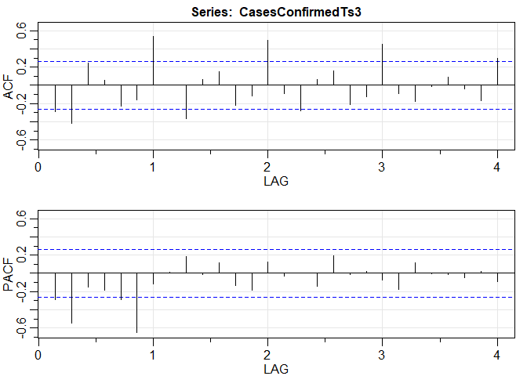

```
##       [,1]  [,2]  [,3]  [,4]  [,5]  [,6]  [,7] [,8]  [,9] [,10] [,11] [,12]
## ACF  -0.29 -0.42  0.24  0.05 -0.22 -0.16  0.54 0.00 -0.36  0.06  0.15 -0.22
## PACF -0.29 -0.54 -0.15 -0.18 -0.28 -0.65 -0.11 0.02  0.18 -0.01  0.12 -0.14
##      [,13] [,14] [,15] [,16] [,17] [,18] [,19] [,20] [,21] [,22] [,23] [,24]
## ACF  -0.11  0.50 -0.09 -0.28  0.06  0.16 -0.21 -0.12  0.45 -0.09 -0.17 -0.01
## PACF -0.18  0.12 -0.03  0.00 -0.14  0.19 -0.01  0.02 -0.07 -0.18  0.12 -0.01
##      [,25] [,26] [,27] [,28]
## ACF   0.09 -0.04 -0.17  0.30
## PACF -0.01 -0.05  0.02 -0.09
```

```r
acf2(CasesConfirmedTs3, max.lag = 28)
```

In this example, we can see a spike at every weekly lag in ACF and only one spike at weekly lag 1 in PACF, which suggests SAR(1). You can also see there are 2 spikes at daily lag 1 and 2 in both ACF and PACF plots. This time, it seems that PACF is tailing off, and ACF cuts off, which suggests MA(2) term.

Sometimes these plots are tricky to interpret, and it’s totally ok. Do not spend too much time trying to over-analyze it. It’s faster to build a few models with different orders and then compare the results.

#### Forecasting with ARIMA Models

Let’s generate ACF and PACF for our time series, showing all the transformations we had done along the way, and determine the model order.

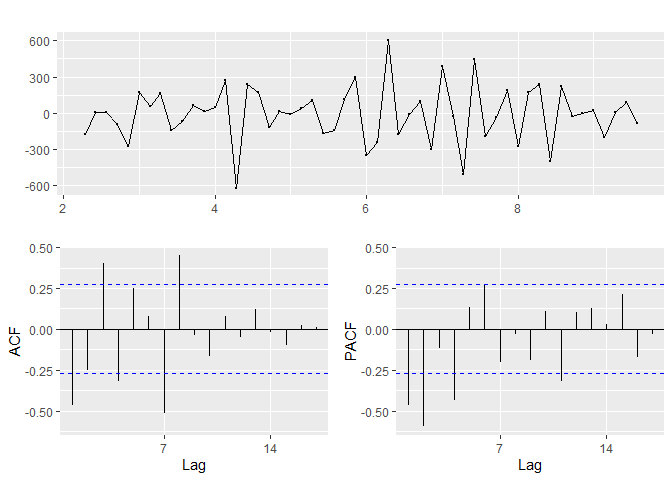

```r
CasesConfirmedTs%>%
  BoxCox(lambda=lambda)%>% #Box-Cox transformation to stabilize the variance
  diff(lag=7)%>% #first order seasonal differencing to remove seasonal trends
  diff(lag=1, differences = 2)%>% #non-seasonal differencing of the 2nd order to remove non-seasonal trends
  ggtsdisplay()
```

Seasonal ARIMA Terms:

We can see 1 seasonal spike at lag=7 in ACF and no seasonal spikes in PACF, which suggests an SMA(1) term.

Non-seasonal ARIMA Terms:

To identify significant non-seasonal terms, we need to look at the lags before the 1st seasonal lag. Remember what I said earlier? This can get pretty tricky. In this case, it appears that ACF breaks after lag 1, and PACF tails off, which suggests an MA(1) term.

We may discover that there are other significant lags as there are a few more spikes in the plot, but we will deal with this later.

Now, we need to put all the terms together to create a model. Let’s take the time and review each term and how we derived it.

Non-seasonal Terms:

AR term order = 0: PACF tailed off before the first seasonal lag, and ACF cut off after the first non-seasonal lag, suggesting no AR terms and an MA(1) term

Differencing order = 2: recall that we differenced our time series twice to remove the trend

MA term order = 1: PACF tailed off before the first seasonal lag, and ACF cut off after the first non-seasonal lag, suggesting MA(1) term

Seasonal Terms:

SAR term order = 0: PACF showed no significant seasonal lags

Seasonal Differencing = 1: recall that we differenced our time series once to remove the seasonal trend

SMA term order = 1: ACF showed one significant seasonal lag, suggesting SMA(1)

Frequency = 7

This is how the model looks like after we put all the terms together: ARIMA(0,2,1)x(0,1,1)[7]

Now, let’s go ahead and fit the model. Remember to use the original time series after the Box-Cox transformation but before the differencing since we are already specifying the differencing order in the model.

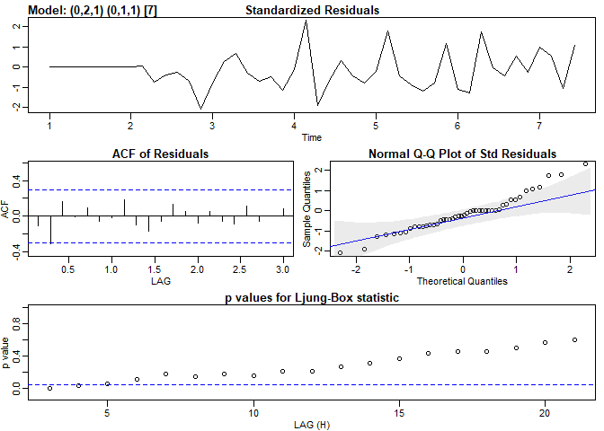

```r
#Create a training set from the Box-Cox transformed time series
train2 <- subset(CasesConfirmedTs2, end=length(CasesConfirmedTs2)-15)

#Fit ARIMA(0,2,1)x(0,1,0)[7]
sarima.fit1 <- sarima(train2, 0,2,1,0,1,1,7)
```

When we use the sarima() function to fit the ARIMA model, as shown above, it automatically returns the model fit metrics. Since ARIMA is similar to the linear regression model, we need to make sure that the residuals are normally distributed and are free from any trends. To do that, we need to analyze the Standardized Residuals plot and the Normal QQ plot. It appears that our residuals slightly diverge from normality on one end. It does not look significant to me, but we can always check using a statistical test for normality. One such test is Shapiro-Wilk normality test that compares the sample distribution to a normal one to assess if the data show any severe deviation from normality.

```r
shapiro.test(resid(sarima.fit1$fit))
```

```
##
##  Shapiro-Wilk normality test
##
## data:  resid(sarima.fit1$fit)
## W = 0.95971, p-value = 0.1117
```

The test returned the p-value that is larger than 0.05, which means that our residuals are not significantly different from a normal distribution.

Secondly, we need to examine the ACF of residuals to make sure that there are no spikes above or below the blue line. If there are any, it would mean there is still some useful information we are not accounting for in our model. For the most part, all of the correlations in ACF are not significant. There is one that is on the borderline, but it’s nothing to worry about.

Finally, we need to look at the Ljung-Box plot to make sure that most of the p values are outside of the significant p area (0.05). This test tells us if any significant autocorrelations remain unaccounted for by the model. If no p-values are below 0.05, then all significant autocorrelations had been considered. Our data shows two p-values in the significant p area, but most of them look fine.

It appears that our model passed all the tests, and we can proceed to creating a forecast. However, let’s say we did not pass the residuals test, what do we do then?

In that case, we could adjust the model by adding a new term(s) and analyze the effect on the residuals. For this demonstration, I will fit another ARIMA model and add one more MA term to the model’s order.

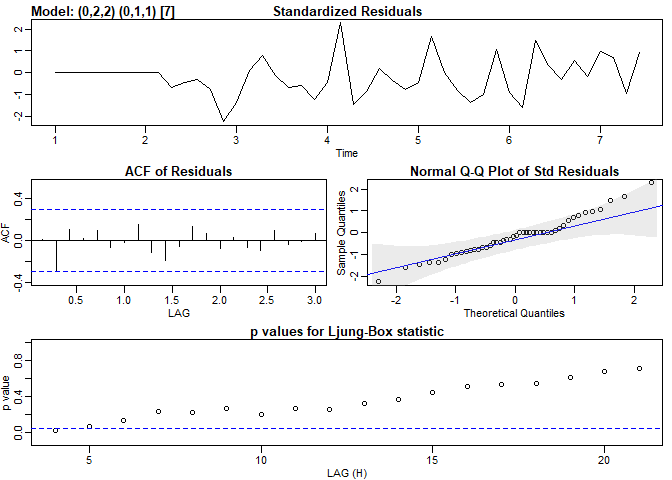

```r
#Fit ARIMA(0,2,2)x(0,1,1)[7]
sarima.fit2 <- sarima(train2, 0,2,2,0,1,1,7)
```

This model does not show any drastic changes in the residuals plots. There are slight improvements to the QQ plot and the Ljung-Box statistic plot.

Since both of these models pass the residuals test, how do we know which one is better?

We can compare ARIMA models by using AIC, AICc, or BIC. All three of them estimate prediction error. The model that shows the lowest prediction error is a better fit. AICc is commonly used with time series because it adds a penalty for model complexity.

```r
sarima.fit1
```

```
## $fit
##
## Call:
## stats::arima(x = xdata, order = c(p, d, q), seasonal = list(order = c(P, D,
##     Q), period = S), xreg = constant, transform.pars = trans, fixed = fixed,
##     optim.control = list(trace = trc, REPORT = 1, reltol = tol))
##
## Coefficients:
##           ma1     sma1   constant
##       -0.9898  -0.7475    29.9408
## s.e.   0.1426   0.2994  9268.5960
##
## sigma^2 estimated as 17364:  log likelihood = -241.46,  aic = 490.92
##
## $degrees_of_freedom
## [1] 34
##
## $ttable
##          Estimate        SE t.value p.value
## ma1       -0.9898    0.1426 -6.9403  0.0000
## sma1      -0.7475    0.2994 -2.4968  0.0175
## constant  29.9408 9268.5960  0.0032  0.9974
##
## $AIC
## [1] 11.41663
##
## $AICc
## [1] 11.43094
##
## $BIC
## [1] 11.56648
```

```r
sarima.fit2
```

```
## $fit
##
## Call:
## stats::arima(x = xdata, order = c(p, d, q), seasonal = list(order = c(P, D,
##     Q), period = S), xreg = constant, transform.pars = trans, fixed = fixed,
##     optim.control = list(trace = trc, REPORT = 1, reltol = tol))
##
## Coefficients:
##           ma1     ma2     sma1   constant
##       -1.1847  0.1956  -0.6852    29.9411
## s.e.   0.3143  0.2652   0.2836  9268.6438
##
## sigma^2 estimated as 17642:  log likelihood = -241.31,  aic = 492.61
##
## $degrees_of_freedom
## [1] 33
##
## $ttable
##          Estimate        SE t.value p.value
## ma1       -1.1847    0.3143 -3.7696  0.0006
## ma2        0.1956    0.2652  0.7375  0.4660
## sma1      -0.6852    0.2836 -2.4157  0.0214
## constant  29.9411 9268.6438  0.0032  0.9974
##
## $AIC
## [1] 11.45607
##
## $AICc
## [1] 11.48055
##
## $BIC
## [1] 11.64338
```

Our first model is a better fit for the data because it shows smaller AIC, AICc, and BIC. Also, the second MA term added in the second model does not seem to be significant (p-value > 0.05).

Let’s still create forecasts for both of the models and compare forecast errors as well.

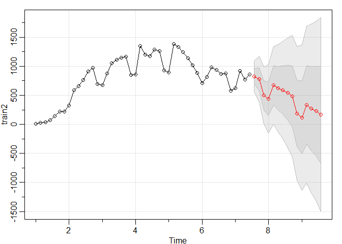

```r
#Forecast ARIMA(0,2,1)x(0,1,0)[7]
sarima.forecast1 <- sarima.for(train2, n.ahead=15, 0,2,1,0,1,1,7)
```

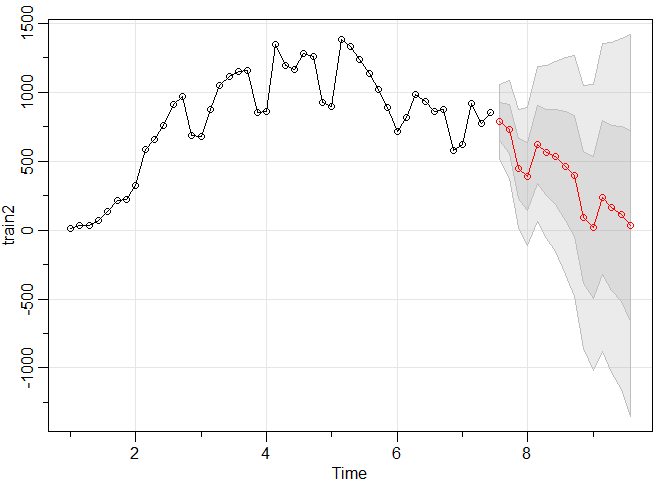

```r
#Forecast ARIMA(0,2,2)x(0,1,0)[7]
sarima.forecast2 <- sarima.for(train2, n.ahead=15, 0,2,2,0,1,1,7)
```

Both forecasts look pretty good. Let’s put them against the actuals.

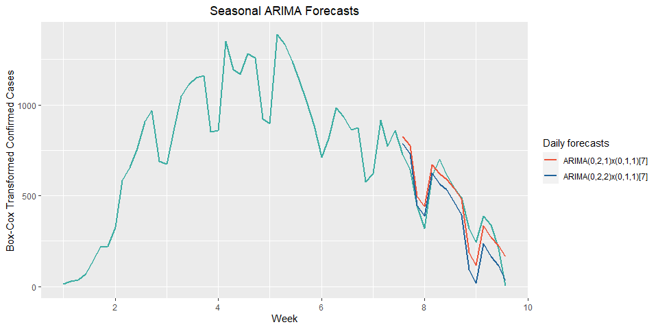

```r
autoplot(CasesConfirmedTs2, main = "Seasonal ARIMA Forecasts", ylab = "Box-Cox Transformed Confirmed Cases", xlab = "Week", size = 0.8, color = "#3CAEA3") +
   autolayer(sarima.forecast1$pred, series = "ARIMA(0,2,1)x(0,1,1)[7]", size = 0.8)+
   autolayer(sarima.forecast2$pred, series = "ARIMA(0,2,2)x(0,1,1)[7]", size = 0.8)+
  scale_color_manual(values = c("ARIMA(0,2,1)x(0,1,1)[7]" = "#ED553B", "ARIMA(0,2,2)x(0,1,1)[7]"="#20639B"))+
  guides(color=guide_legend(title="Daily forecasts"))+
  theme(plot.title = element_text(hjust = 0.5))
```

Although both forecasts are pretty close, I think it’s clear that our first model, ARIMA(0,2,1)x(0,1,1)[7], produced a more accurate forecast.

However, let’s still calculate MAE and RMSE to see the difference in error measures between the two models.

```r
#ARIMA(0,2,1)x(0,1,1)[7]
knitr::kable(accuracy(sarima.forecast1$pred, CasesConfirmedTs))
```

|  | ME | RMSE | MAE | MPE | MAPE | ACF1 | Theil’s U |
| --- | --- | --- | --- | --- | --- | --- | --- |
| Test set | 1098.371 | 1251.613 | 1119.708 | -110.9809 | 244.6294 | 0.5088685 | 1.424362 |

```r
#ARIMA(0,2,2)x(0,1,1)[7]
knitr::kable(accuracy(sarima.forecast2$pred, CasesConfirmedTs))
```

|  | ME | RMSE | MAE | MPE | MAPE | ACF1 | Theil’s U |
| --- | --- | --- | --- | --- | --- | --- | --- |
| Test set | 1174.491 | 1309.104 | 1178.084 | 42.58439 | 102.4735 | 0.4977672 | 1.515906 |

#### Auto.Arima

There is another way for us to find the optimal model order for ARIMA, one that does not require such exhaustive analysis. Supposedly, by just calling auto.arima(), we should get the best ARIMA order for our data.

What?! Did we really have to go through all this if we could have had an algorithm do it for us?

Hang on, let’s see what auto.arima thinks the best model order would be for our data.

```r
#auto.arima
auto.arima <- auto.arima(train2)
auto.arima
```

```
## Series: train2
## ARIMA(0,1,0)(0,1,1)[7]
##
## Coefficients:
##          sma1
##       -0.8271
## s.e.   0.4524
##
## sigma^2 estimated as 17087:  log likelihood=-242.3
## AIC=488.59   AICc=488.94   BIC=491.87
```

Auto.arima says that the best order is ARIMA(0,1,0)(0,1,1)[7]. Let’s check the residuals and then compare how this model performs against its sister.

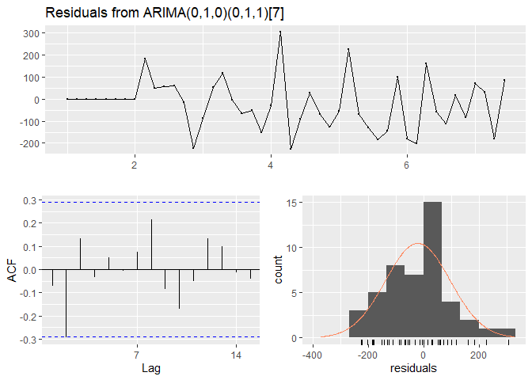

```
##
##  Ljung-Box test
##
## data:  Residuals from ARIMA(0,1,0)(0,1,1)[7]
## Q* = 9.1863, df = 8, p-value = 0.3268
##
## Model df: 1.   Total lags used: 9
```

```r
#check residuals
checkresiduals(auto.arima)
```

The model passed all the residual tests: the residuals are random, more or less normally distributed, and without any significant autocorrelations.

Now, let’s compare the models’ performance.

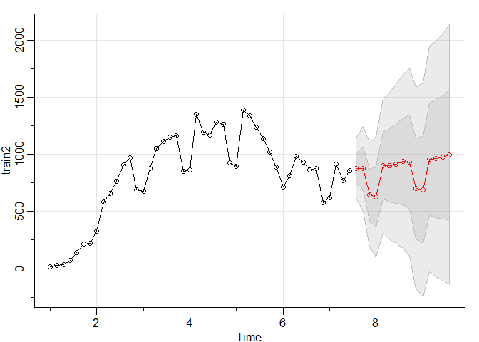

```r
#Generate a forecast
sarima.forecast3 <- sarima.for(train2, n.ahead=15, 0,1,0,0,1,1,7)
```

Auto.arima’s forecast does not look anywhere close! This is why we learned it the hard way so that we can produce a better forecast than the algorithm.

#### Convert a Box-Cox Transformed Series back to Original Scale

Before we call it a day, remember that we still have that Holt-Winters model we built at the beginning of this tutorial that also showed a pretty good forecast. We should go back and compare it against our best ARIMA model.

Recall that at this point, our ARIMA model is based on the Box-Cox transformed time series, so it’s at a different scale compared to the Holt-Winters model. To be able to compare them, we need to have them on the same scale. Thus, we need to convert the ARIMA model predictions back to the original scale of our time series and then compare the two models.

```r
#Converting ARIMA predictions back to the original scale
sarima.forecast1.trfmd <- (sarima.forecast1$pred*lambda+1)^(1/lambda) #use the same lambda used in the Box-Cox transformation
sarima.forecast1.trfmd
```

```
## Time Series:
## Start = c(7, 5)
## End = c(9, 5)
## Frequency = 7
##  [1] 3260.6626 3017.4864 1737.9671 1489.7900 2523.9070 2289.4202 2147.7590
##  [8] 1942.2289 1663.9686  521.7019  288.4301 1064.4879  816.6991  652.2973
## [15]  446.1791
```

Ok, now we are ready to compare the two models, so let’s plot the forecasts against the actuals.

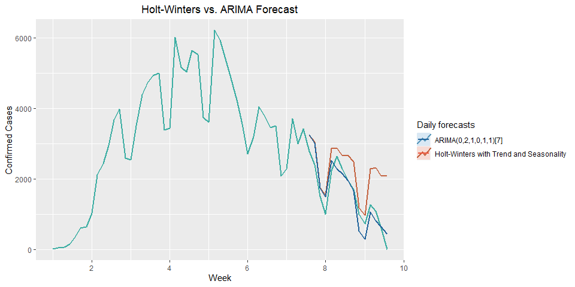

```r
autoplot(CasesConfirmedTs, main = "Holt-Winters vs. ARIMA Forecast", ylab = "Confirmed Cases", xlab = "Week", size=0.8, color="#3CAEA3") +
    autolayer(es.fit.a, series="Holt-Winters with Trend and Seasonality", PI=FALSE, size=0.8)+
    autolayer(sarima.forecast1.trfmd, series = "ARIMA(0,2,1,0,1,1)[7]", size=0.8)+
   scale_color_manual(values = c("Holt-Winters with Trend and Seasonality" = "#ED553B", "ARIMA(0,2,1,0,1,1)[7]"="#20639B"))+
  guides(color=guide_legend(title="Daily forecasts"))+
  theme(plot.title = element_text(hjust = 0.5))
```

We can quickly tell by looking at the plot that our ARIMA model is a much better fit for the data. Still, let us check the model accuracy measures.

```r
knitr::kable(accuracy(sarima.forecast1.trfmd, CasesConfirmedTs))
```

|  | ME | RMSE | MAE | MPE | MAPE | ACF1 | Theil’s U |
| --- | --- | --- | --- | --- | --- | --- | --- |
| Test set | -42.73234 | 352.6578 | 301.7063 | -486.147 | 509.0567 | 0.5576645 | 0.5520743 |

Nice work! We have a model that can predict net new cases of coronavirus with an average error of plus-minus 300 cases.

I hope you found this tutorial helpful and will use what you learned to make a kickass forecast in your next project!